# PartII_slide_deck slides

## How Prosper Rating affects loan borrowing

Created by Enock Chesire

September 2022

## Overview

This project is on a data set from Prosper, which is America’s first marketplace lending platform, with over $7 billion in funded loans. The company uses a rating system that takes into account data such as employment status, income and debt-to-income-ratio to determine the amount to be issued.

This report seeks to find out how the prosper rating could influence how loans are given by the company.

## Dataset Overview

This data set contains 113,937 loans with 81 variables on each loan, including loan amount, borrower rate (or interest rate), current loan status, borrower income, borrower employment status, borrower credit history, and the latest payment information some of which will not be necessary for this analysis.

## How Prosper works

- Loan requests are assigned letter grades starting from AA(low risk) to HR(high risk)
- Data exploration shows how this grading affects the chances of people getting loans which is captured by Borrower APR

**How are Prosper ratings, Income range and Employment status are distributed**

- From the charts below, employed people seem to get loans compared to the rest of the people. This could be due to the security of their jobs and thus their ability to repay the loans.
- C is the most popular rating. Listings rated AA are the least popular. Income range seems to be skewed towards the middle income earners with borrowers between 25000 and 74999 being the majority. This indicates that those people who are employed are most likely to get more loans.

**ProsperRating Vs Income range Vs EmploymentStatus**

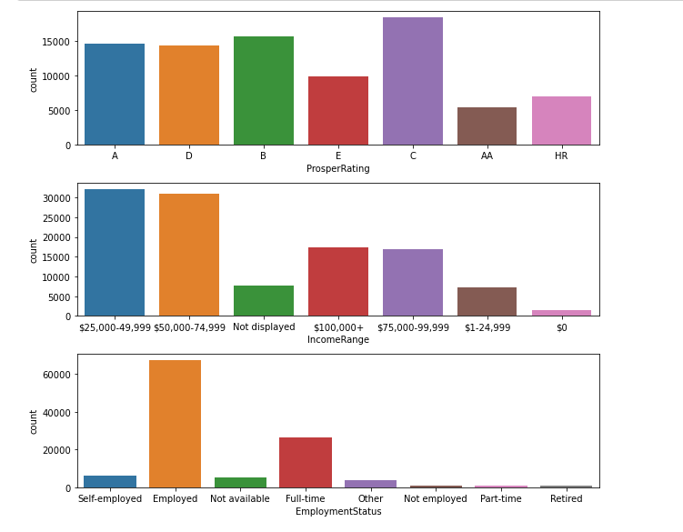

**Relationship between Employment status and the numerical variables: BorrowerAPR, StatedMonthlyIncome, LoanOriginalAmount, DebtToIncomeRatio**

**Employment status vs BorrowerAPR, StatedMonthlyIncome, LoanOriginalAmount and DebtToIncomeRatio**

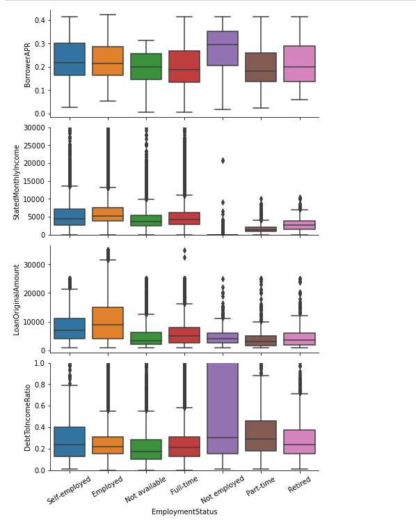

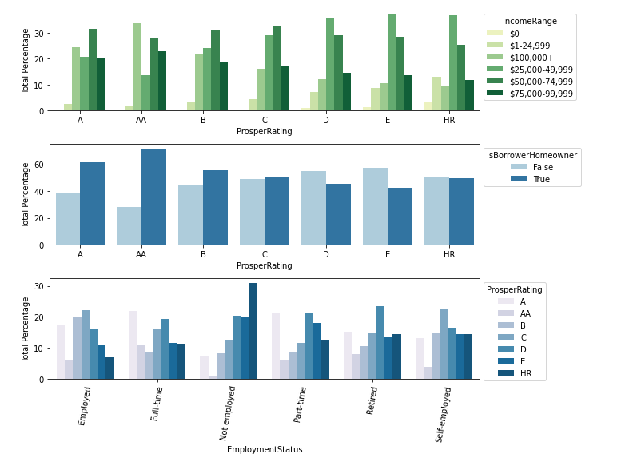